# Process_raw_data

Author

Alexander W. Gofton & Emily Smith

Published

March 13, 2026

## Setup

Load CSIRO colour palette and required packages for spatial data, data manipulation, and plot composition.

```r
source("code/CSIRO_colours.R")

library(sf)
library(tidyverse)
library(patchwork)
```

## Load Data

Import the deduplicated and full (with repeat tests) datasets, filtered to 2014-2024.

```r
data_no_multi <- read.csv("data/preprocessed_with_SA_info_no_multi.csv") %>%
  filter(YOT >= 2014 & YOT <= 2024)

data_with_multi <- read.csv("data/preprocessed_with_SA_info.csv") %>%
  filter(YOT >= 2014 & YOT <= 2024)
```

# Annual Testing Summaries

Calculate yearly totals of tests performed, positive results, and positivity rates for both unique patient and all-test perspectives.

## Unique Patients

```r
# Summarise data_no_multi
pos_annual_prop_no_multi <- data_no_multi %>%
  group_by(YOT) %>%
  summarise(
    total_tests = n(),
    positive_tests = sum(Status == "Positive", na.rm = TRUE)
  ) %>%
  mutate(pos_prop = (positive_tests / total_tests) * 100) %>%
  mutate(pos_prop = round(pos_prop, 2)) %>%
  rename(Year = YOT) %>%
  # Remove early testing years and 2025 which is an incomplete year
  filter(
    Year != 2012,
    Year != 2013,
    Year != 2025
  )

cat("=== SUMMARY TABLE UNIQUE PATIENTS ===\n")
print(pos_annual_prop_no_multi)
```

```
=== SUMMARY TABLE UNIQUE PATIENTS ===
# A tibble: 11 × 4
    Year total_tests positive_tests pos_prop
   <int>       <int>          <int>    <dbl>
 1  2014         610            357     58.5
 2  2015         800            297     37.1
 3  2016         792            368     46.5
 4  2017        1169            421     36.0
 5  2018        1239            408     32.9
 6  2019        1277            372     29.1
 7  2020        1230            356     28.9
 8  2021        1484            500     33.7
 9  2022        1386            459     33.1
10  2023        1934            700     36.2
11  2024        2155            787     36.5
```

## All Tests (Including Repeats)

```r
# Summarise data_with_multi
pos_annual_prop_multi <- data_with_multi %>%
  group_by(YOT) %>%
  summarise(
    total_tests = n(),
    positive_tests = sum(Status == "Positive", na.rm = TRUE)
  ) %>%
  mutate(pos_prop = (positive_tests / total_tests) * 100) %>%
  mutate(pos_prop = round(pos_prop, 2)) %>%
  rename(Year = YOT) %>%
  # Remove early testing years and 2025 which is an incomplete year
  filter(
    Year != 2012,
    Year != 2013,
    Year != 2025
  )

cat("=== SUMMARY TABLE ALL TESTS ===\n")
print(pos_annual_prop_multi)
```

```
=== SUMMARY TABLE ALL TESTS ===
# A tibble: 11 × 4
    Year total_tests positive_tests pos_prop
   <int>       <int>          <int>    <dbl>
 1  2014         629            366     58.2
 2  2015         835            325     38.9
 3  2016         871            430     49.4
 4  2017        1283            512     39.9
 5  2018        1384            524     37.9
 6  2019        1515            541     35.7
 7  2020        1442            509     35.3
 8  2021        1801            733     40.7
 9  2022        1729            705     40.8
10  2023        2368           1020     43.1
11  2024        2707           1217     45.0
```

# Compound Annual Growth Rates (CAGR)

Quantify the rate of growth in testing volume, positive case numbers, and positivity rate over defined time periods using log-linear regression with 95% confidence intervals.

## Year-over-Year Change (Unique Patients)

Calculate year-over-year absolute and percentage change in positive case numbers.

```r
positive_tests_trend_no_multi <- pos_annual_prop_no_multi %>%
  filter(Year >= 2014, Year <= 2024) %>%
  arrange(Year) %>%
  mutate(
    # Calculate year-over-year percentage change in positive tests
    yoy_change = (positive_tests - lag(positive_tests)) /
      lag(positive_tests) *
      100,
    yoy_change = round(yoy_change, 2)
  ) %>%
  dplyr::select(Year, positive_tests, total_tests, pos_prop, yoy_change)
```

```r
positive_tests_trend_with_multi <- pos_annual_prop_multi %>%
  filter(Year >= 2014, Year <= 2024) %>%
  arrange(Year) %>%
  mutate(
    # Calculate year-over-year percentage change in positive tests
    yoy_change = (positive_tests - lag(positive_tests)) /
      lag(positive_tests) *
      100,
    yoy_change = round(yoy_change, 2)
  ) %>%
  dplyr::select(Year, positive_tests, total_tests, pos_prop, yoy_change)
```

```r
library(boot)

calculate_cagr_with_ci <- function(data, value_col, start_year, end_year) {
  # Filter data for period
  period_data <- data %>%
    filter(Year >= start_year, Year <= end_year)

  # Fit log-linear model
  model <- lm(log(get(value_col)) ~ Year, data = period_data)

  # Extract coefficients
  coef_year <- coef(model)["Year"]
  se_year <- summary(model)$coefficients["Year", "Std. Error"]

  # Calculate CAGR and CI
  cagr <- (exp(coef_year) - 1) * 100
  cagr_lower <- (exp(coef_year - 1.96 * se_year) - 1) * 100
  cagr_upper <- (exp(coef_year + 1.96 * se_year) - 1) * 100

  return(list(
    cagr = cagr,
    ci_lower = cagr_lower,
    ci_upper = cagr_upper,
    se = se_year,
    model = model
  ))
}
```

## Testing Volume CAGR

Estimate compound annual growth rates for testing volume across pre- and post-2021 periods.

```r
# Testing volume 2014-2021
test_2014_2021 <- calculate_cagr_with_ci(
  positive_tests_trend_no_multi,
  "total_tests",
  2014,
  2021
)
cat("Testing Volume CAGR 2014-2021:\n")
cat(
  "  ",
  round(test_2014_2021$cagr, 2),
  "% (95% CI: ",
  round(test_2014_2021$ci_lower, 2),
  "-",
  round(test_2014_2021$ci_upper, 2),
  "%)\n\n",
  sep = ""
)

# Testing volume 2022-2024
test_2022_2024 <- calculate_cagr_with_ci(
  positive_tests_trend_no_multi,
  "total_tests",
  2022,
  2024
)
cat("Testing Volume CAGR 2022-2024:\n")
cat(
  "  ",
  round(test_2022_2024$cagr, 2),
  "% (95% CI: ",
  round(test_2022_2024$ci_lower, 2),
  "-",
  round(test_2022_2024$ci_upper, 2),
  "%)\n\n",
  sep = ""
)
```

```
Testing Volume CAGR 2014-2021:
  12.46% (95% CI: 8.39-16.68%)

Testing Volume CAGR 2022-2024:
  24.69% (95% CI: 9.79-41.62%)
```

## Positive Cases CAGR

Estimate compound annual growth rates for the number of positive cases across pre- and post-2020 periods.

```r
# Positive cases 2014-2020
pos_2014_2020 <- calculate_cagr_with_ci(
  positive_tests_trend_no_multi,
  "positive_tests",
  2014,
  2020
)
cat("Positive Cases CAGR 2014-2020:\n")
cat(
  "  ",
  round(pos_2014_2020$cagr, 2),
  "% (95% CI: ",
  round(pos_2014_2020$ci_lower, 2),
  "-",
  round(pos_2014_2020$ci_upper, 2),
  "%)\n\n",
  sep = ""
)

# Positive cases 2020-2024
pos_2020_2024 <- calculate_cagr_with_ci(
  positive_tests_trend_no_multi,
  "positive_tests",
  2020,
  2024
)
cat("Positive Cases CAGR 2020-2024:\n")
cat(
  "  ",
  round(pos_2020_2024$cagr, 2),
  "% (95% CI: ",
  round(pos_2020_2024$ci_lower, 2),
  "-",
  round(pos_2020_2024$ci_upper, 2),
  "%)\n\n",
  sep = ""
)
```

```
Positive Cases CAGR 2014-2020:
  1.97% (95% CI: -2.29-6.4%)

Positive Cases CAGR 2020-2024:
  21.2% (95% CI: 12.32-30.79%)
```

## Positivity Rate CAGR

Estimate compound annual growth rates for the positivity rate across pre- and post-2019 periods.

```r
# Pos rate 2014 - 2019
pos.rate_2014_2019 <- calculate_cagr_with_ci(
  positive_tests_trend_no_multi,
  "pos_prop",
  2014,
  2019
)
cat("Positive RATE CAGR 2014-2019:\n")
cat(
  "  ",
  round(pos.rate_2014_2019$cagr, 2),
  "% (95% CI: ",
  round(pos.rate_2014_2019$ci_lower, 2),
  "-",
  round(pos.rate_2014_2019$ci_upper, 2),
  "%)\n\n",
  sep = ""
)

# Pos rate 2020-2024
pos.rate_2020_2024 <- calculate_cagr_with_ci(
  positive_tests_trend_no_multi,
  "pos_prop",
  2020,
  2024
)
cat("Positive RATE CAGR 2020-2024:\n")
cat(
  "  ",
  round(pos.rate_2020_2024$cagr, 2),
  "% (95% CI: ",
  round(pos.rate_2020_2024$ci_lower, 2),
  "-",
  round(pos.rate_2020_2024$ci_upper, 2),
  "%)\n\n",
  sep = ""
)
```

```
Positive RATE CAGR 2014-2019:
  -11.06% (95% CI: -16.67--5.07%)

Positive RATE CAGR 2020-2024:
  5.52% (95% CI: 2.6-8.52%)
```

# Segmented Regression Analysis

Fit piecewise linear regression models to identify structural breakpoints in testing trends, with a fixed breakpoint at 2020 for positive cases.

```r
library(segmented)

time_model_pos <- lm(positive_tests ~ Year, data = pos_annual_prop_no_multi)

# Your segmented model with fixed breakpoint at 2020
segmented_model_pos <- segmented(
  time_model_pos,
  seg.Z = ~Year,
  psi = 2020,
  control = seg.control(it.max = 0)
)

cat("=== BREAKPOINT ANALYSIS (Fixed at 2020) ===\n")
summary(segmented_model_pos)

# MANUALLY EXTRACT SLOPES from coefficients
coefs <- coef(segmented_model_pos)
coef_summary <- summary(segmented_model_pos)$coefficients

# First segment slope (before 2020)
slope_before <- coefs["Year"]
se_before <- coef_summary["Year", "Std. Error"]

# Second segment slope (after 2020)
# Total slope after breakpoint = Year + U1.Year
slope_after <- coefs["Year"] + coefs["U1.Year"]
# SE for sum of coefficients (using variance formula)
var_after <- coef_summary["Year", "Std. Error"]^2 +
  coef_summary["U1.Year", "Std. Error"]^2 +
  2 * vcov(segmented_model_pos)["Year", "U1.Year"]
se_after <- sqrt(var_after)

cat("\n=== SEGMENT SLOPES ===\n")
cat(
  "First segment (2014-2020):",
  round(slope_before, 2),
  "±",
  round(se_before, 2),
  "cases/year\n"
)
cat(
  "Second segment (2020-2024):",
  round(slope_after, 2),
  "±",
  round(se_after, 2),
  "cases/year\n"
)
cat("Acceleration factor:", round(slope_after / slope_before, 2), "×\n")

# Calculate R² for the first segment (2014-2020)
first_segment_data <- pos_annual_prop_no_multi %>%
  filter(Year <= 2020)

first_segment_model <- lm(positive_tests ~ Year, data = first_segment_data)

cat("\n=== FIRST SEGMENT (2014-2020) ===\n")
cat("Slope:", round(coef(first_segment_model)["Year"], 2), "cases/year\n")
cat(
  "SE:",
  round(summary(first_segment_model)$coefficients["Year", "Std. Error"], 2),
  "\n"
)
cat("R²:", round(summary(first_segment_model)$r.squared, 4), "\n")
cat("Adjusted R²:", round(summary(first_segment_model)$adj.r.squared, 4), "\n")
cat(
  "p-value:",
  format.pval(
    summary(first_segment_model)$coefficients["Year", "Pr(>|t|)"],
    digits = 4
  ),
  "\n"
)

# Calculate R² for the second segment (2021-2024)
second_segment_data <- pos_annual_prop_no_multi %>%
  filter(Year > 2020)

second_segment_model <- lm(positive_tests ~ Year, data = second_segment_data)

cat("\n=== SECOND SEGMENT (2021-2024) ===\n")
cat("Slope:", round(coef(second_segment_model)["Year"], 2), "cases/year\n")
cat(
  "SE:",
  round(summary(second_segment_model)$coefficients["Year", "Std. Error"], 2),
  "\n"
)
cat("R²:", round(summary(second_segment_model)$r.squared, 4), "\n")
cat("Adjusted R²:", round(summary(second_segment_model)$adj.r.squared, 4), "\n")
cat(
  "p-value:",
  format.pval(
    summary(second_segment_model)$coefficients["Year", "Pr(>|t|)"],
    digits = 4
  ),
  "\n"
)

# Overall segmented model R²
cat("\n=== OVERALL SEGMENTED MODEL ===\n")
cat("R²:", round(summary(segmented_model_pos)$r.squared, 4), "\n")
cat("Adjusted R²:", round(summary(segmented_model_pos)$adj.r.squared, 4), "\n")
cat("AIC:", round(AIC(segmented_model_pos), 2), "\n")

# Compare with simple linear model (no breakpoint)
simple_model <- lm(positive_tests ~ Year, data = pos_annual_prop_no_multi)
cat("\n=== COMPARISON: Simple Linear Model ===\n")
cat("R²:", round(summary(simple_model)$r.squared, 4), "\n")
cat("AIC:", round(AIC(simple_model), 2), "\n")
cat(
  "AIC improvement with breakpoint:",
  round(AIC(simple_model) - AIC(segmented_model_pos), 2),
  "\n"
)
```

```
=== BREAKPOINT ANALYSIS (Fixed at 2020) ===

Call:
lm(formula = positive_tests ~ Year + U1.Year, data = mfExt)

Residuals:
     Min       1Q   Median       3Q      Max
-110.755  -10.155    7.204   30.245   56.387

Coefficients:
             Estimate Std. Error t value Pr(>|t|)
(Intercept) -7334.040  18889.118  -0.388  0.70795
Year            3.817      9.364   0.408  0.69424
U1.Year        93.029     21.477   4.331  0.00251 **
---
Signif. codes:  0 '***' 0.001 '**' 0.01 '*' 0.05 '.' 0.1 ' ' 1

Residual standard error: 54.18 on 8 degrees of freedom
Multiple R-squared:  0.8998,    Adjusted R-squared:  0.8748
F-statistic: 35.93 on 2 and 8 DF,  p-value: 0.0001007


=== SEGMENT SLOPES ===
First segment (2014-2020): 3.82 ± 9.36 cases/year
Second segment (2020-2024): 96.85 ± 14.61 cases/year
Acceleration factor: 25.37 ×

=== FIRST SEGMENT (2014-2020) ===
Slope: 6.68 cases/year
SE: 7.78
R²: 0.1284
Adjusted R²: -0.046
p-value: 0.4301

=== SECOND SEGMENT (2021-2024) ===
Slope: 110.2 cases/year
SE: 36.88
R²: 0.817
Adjusted R²: 0.7255
p-value: 0.09612

=== OVERALL SEGMENTED MODEL ===
R²: 0.8998
Adjusted R²: 0.8748
AIC: 123.54

=== COMPARISON: Simple Linear Model ===
R²: 0.6649
AIC: 134.83
AIC improvement with breakpoint: 11.28
```

```r
positive_tests_trend_no_multi <- pos_annual_prop_no_multi %>%
  filter(Year >= 2014, Year <= 2024) %>%
  arrange(Year) %>%
  mutate(
    # Calculate year-over-year absolute change
    yoy_absolute_change = positive_tests - lag(positive_tests),
    # Calculate year-over-year percentage change in positive tests
    yoy_change = (positive_tests - lag(positive_tests)) /
      lag(positive_tests) *
      100,
    yoy_change = round(yoy_change, 2)
  ) %>%
  dplyr::select(
    Year,
    positive_tests,
    yoy_absolute_change,
    yoy_change,
    total_tests,
    pos_prop
  )
```

## Year-over-Year Change Summary

Calculate and compare mean year-over-year absolute changes in positive case numbers between the pre-2020 and post-2020 periods.

```r
# Calculate mean YoY absolute change for 2014-2020 period
mean_yoy_2014_2020 <- positive_tests_trend_no_multi %>%
  filter(Year >= 2014, Year <= 2020) %>%
  summarise(
    mean_yoy_absolute = mean(yoy_absolute_change, na.rm = TRUE),
    median_yoy_absolute = median(yoy_absolute_change, na.rm = TRUE),
    sd_yoy_absolute = sd(yoy_absolute_change, na.rm = TRUE),
    n_years = sum(!is.na(yoy_absolute_change))
  )

cat("=== MEAN YEAR-OVER-YEAR CHANGE (2014-2020) ===\n")
print(mean_yoy_2014_2020)

cat(
  "\nMean YoY absolute change:",
  round(mean_yoy_2014_2020$mean_yoy_absolute, 2),
  "cases/year\n"
)
cat(
  "Median YoY absolute change:",
  round(mean_yoy_2014_2020$median_yoy_absolute, 2),
  "cases/year\n"
)
cat("SD:", round(mean_yoy_2014_2020$sd_yoy_absolute, 2), "\n")
cat("Number of year-to-year changes:", mean_yoy_2014_2020$n_years, "\n")

# Compare with 2021-2024 period
mean_yoy_2021_2024 <- positive_tests_trend_no_multi %>%
  filter(Year > 2020) %>%
  summarise(
    mean_yoy_absolute = mean(yoy_absolute_change, na.rm = TRUE),
    median_yoy_absolute = median(yoy_absolute_change, na.rm = TRUE),
    sd_yoy_absolute = sd(yoy_absolute_change, na.rm = TRUE),
    n_years = sum(!is.na(yoy_absolute_change))
  )

cat("\n=== MEAN YEAR-OVER-YEAR CHANGE (2021-2024) ===\n")
print(mean_yoy_2021_2024)

cat(
  "\nMean YoY absolute change:",
  round(mean_yoy_2021_2024$mean_yoy_absolute, 2),
  "cases/year\n"
)
cat(
  "Acceleration factor:",
  round(
    mean_yoy_2021_2024$mean_yoy_absolute / mean_yoy_2014_2020$mean_yoy_absolute,
    2
  ),
  "×\n"
)
```

```
=== MEAN YEAR-OVER-YEAR CHANGE (2014-2020) ===
# A tibble: 1 × 4
  mean_yoy_absolute median_yoy_absolute sd_yoy_absolute n_years
              <dbl>               <dbl>           <dbl>   <int>
1            -0.167               -14.5            51.3       6

Mean YoY absolute change: -0.17 cases/year
Median YoY absolute change: -14.5 cases/year
SD: 51.32
Number of year-to-year changes: 6

=== MEAN YEAR-OVER-YEAR CHANGE (2021-2024) ===
# A tibble: 1 × 4
  mean_yoy_absolute median_yoy_absolute sd_yoy_absolute n_years
              <dbl>               <dbl>           <dbl>   <int>
1              108.                116.            118.       4

Mean YoY absolute change: 107.75 cases/year
Acceleration factor: -646.5 ×
```

## Total Tests Breakpoint

Fit a segmented regression to total test counts with an automatically estimated breakpoint to identify when testing volume acceleration occurred.

```r
# Test for structural breaks in the time series
time_model_tests <- lm(total_tests ~ Year, data = pos_annual_prop_no_multi)
segmented_model_tests <- segmented(time_model_tests, seg.Z = ~Year, npsi = 1)

cat("=== BREAKPOINT ANALYSIS ===\n")
print(summary(segmented_model_tests))
print(segmented_model_tests$psi)

# Plot with breakpoint
breakpoint_year <- round(segmented_model_tests$psi[2])
cat("Estimated breakpoint year:", breakpoint_year, "\n")
```

```
=== BREAKPOINT ANALYSIS ===

    ***Regression Model with Segmented Relationship(s)***

Call:
segmented.lm(obj = time_model_tests, seg.Z = ~Year, npsi = 1)

Estimated Break-Point(s):
           Est. St.Err
psi1.Year 2022  0.653

Coefficients of the linear terms:
              Estimate Std. Error t value Pr(>|t|)
(Intercept) -210248.12   38010.44  -5.531 0.000877 ***
Year            104.74      18.84   5.559 0.000852 ***
U1.Year         224.48      88.37   2.540       NA
---
Signif. codes:  0 '***' 0.001 '**' 0.01 '*' 0.05 '.' 0.1 ' ' 1

Residual standard error: 122.1 on 7 degrees of freedom
Multiple R-Squared: 0.9521,  Adjusted R-squared: 0.9316

Boot restarting based on 6 samples. Last fit:
Convergence *not* attained in 30 iterations (rel. change 3.7805e-05)
          Initial Est.    St.Err
psi1.Year      NA 2022 0.6528011
Estimated breakpoint year: 2022
```

## Positivity Rate Breakpoint

Fit a segmented regression to positivity rate with an automatically estimated breakpoint, then extract slopes and model fit statistics for each segment.

```r
# Test for structural breaks in the time series
time_model_PR <- lm(pos_prop ~ Year, data = pos_annual_prop_no_multi)
segmented_model_PR <- segmented(time_model_PR, seg.Z = ~Year, npsi = 1)

cat("=== BREAKPOINT ANALYSIS ===\n")
print(summary(segmented_model_PR))
print(segmented_model_PR$psi)

# Plot with breakpoint
breakpoint_year <- round(segmented_model_PR$psi[2])
cat("Estimated breakpoint year:", breakpoint_year, "\n")
```

```
=== BREAKPOINT ANALYSIS ===

    ***Regression Model with Segmented Relationship(s)***

Call:
segmented.lm(obj = time_model_PR, seg.Z = ~Year, npsi = 1)

Estimated Break-Point(s):
               Est. St.Err
psi1.Year 2018.672   0.88

Coefficients of the linear terms:
             Estimate Std. Error t value Pr(>|t|)
(Intercept) 10583.872   3117.009   3.396   0.0115 *
Year           -5.229      1.546  -3.382   0.0117 *
U1.Year         6.890      1.938   3.555       NA
---
Signif. codes:  0 '***' 0.001 '**' 0.01 '*' 0.05 '.' 0.1 ' ' 1

Residual standard error: 4.889 on 7 degrees of freedom
Multiple R-Squared: 0.7688,  Adjusted R-squared: 0.6697

Boot restarting based on 6 samples. Last fit:
Convergence attained in 2 iterations (rel. change 2.4442e-12)
          Initial     Est.    St.Err
psi1.Year      NA 2018.672 0.8799722
Estimated breakpoint year: 2019
```

```r
# Extract slopes from segmented model
coefs <- coef(segmented_model_PR)

# First segment slope (before 2019 breakpoint)
slope_before_2019 <- coefs["Year"]

cat("=== FIRST SEGMENT (2014-2019) POSITIVITY RATE ===\n")
cat("Slope:", round(slope_before_2019, 3), "% per year\n")

# Calculate R² for the first segment (2014-2019)
first_segment_PR <- pos_annual_prop_no_multi %>%
  filter(Year >= 2014, Year <= 2019)

first_segment_PR_model <- lm(pos_prop ~ Year, data = first_segment_PR)

cat("R²:", round(summary(first_segment_PR_model)$r.squared, 4), "\n")
cat(
  "Adjusted R²:",
  round(summary(first_segment_PR_model)$adj.r.squared, 4),
  "\n"
)
cat(
  "p-value:",
  format.pval(
    summary(first_segment_PR_model)$coefficients["Year", "Pr(>|t|)"],
    digits = 4
  ),
  "\n"
)

# Show full summary
cat("\n=== FULL REGRESSION DETAILS ===\n")
summary(first_segment_PR_model)
```

```
=== FIRST SEGMENT (2014-2019) POSITIVITY RATE ===
Slope: -5.229 % per year
R²: 0.7152
Adjusted R²: 0.644
p-value: 0.03388

=== FULL REGRESSION DETAILS ===

Call:
lm(formula = pos_prop ~ Year, data = first_segment_PR)

Residuals:
       1        2        3        4        5        6
  6.3510 -10.1928   4.0035  -1.5902   0.1861   1.2424

Coefficients:
            Estimate Std. Error t value Pr(>|t|)
(Intercept) 9832.728   3089.941   3.182   0.0335 *
Year          -4.856      1.532  -3.169   0.0339 *
---
Signif. codes:  0 '***' 0.001 '**' 0.01 '*' 0.05 '.' 0.1 ' ' 1

Residual standard error: 6.41 on 4 degrees of freedom
Multiple R-squared:  0.7152,    Adjusted R-squared:  0.644
F-statistic: 10.04 on 1 and 4 DF,  p-value: 0.03388
```

```r
# Extract slopes from segmented model
coefs <- coef(segmented_model_PR)

# Second segment slope (after 2019 breakpoint)
# Total slope after breakpoint = Year + U1.Year
slope_after_2019 <- coefs["Year"] + coefs["U1.Year"]

cat("=== SECOND SEGMENT (2019-2024) POSITIVITY RATE ===\n")
cat("Slope:", round(slope_after_2019, 3), "% per year\n")

# Calculate standard error for second segment slope
coef_summary <- summary(segmented_model_PR)$coefficients
var_after <- coef_summary["Year", "Std. Error"]^2 +
  coef_summary["U1.Year", "Std. Error"]^2 +
  2 * vcov(segmented_model_PR)["Year", "U1.Year"]
se_after <- sqrt(var_after)
cat("SE:", round(se_after, 3), "\n")

# Calculate R² for the second segment (2019-2024)
second_segment_PR <- pos_annual_prop_no_multi %>%
  filter(Year >= 2019, Year <= 2024)

second_segment_PR_model <- lm(pos_prop ~ Year, data = second_segment_PR)

cat("R²:", round(summary(second_segment_PR_model)$r.squared, 4), "\n")
cat(
  "Adjusted R²:",
  round(summary(second_segment_PR_model)$adj.r.squared, 4),
  "\n"
)
cat(
  "p-value:",
  format.pval(
    summary(second_segment_PR_model)$coefficients["Year", "Pr(>|t|)"],
    digits = 4
  ),
  "\n"
)

# Show full summary
cat("\n=== FULL REGRESSION DETAILS ===\n")
summary(second_segment_PR_model)
```

```
=== SECOND SEGMENT (2019-2024) POSITIVITY RATE ===
Slope: 1.661 % per year
SE: 1.169
R²: 0.8859
Adjusted R²: 0.8574
p-value: 0.00508

=== FULL REGRESSION DETAILS ===

Call:
lm(formula = pos_prop ~ Year, data = second_segment_PR)

Residuals:
      1       2       3       4       5       6
 0.3505 -1.5004  1.5888 -0.6421  0.7670 -0.5638

Coefficients:
             Estimate Std. Error t value Pr(>|t|)
(Intercept) -3324.491    602.426  -5.519  0.00526 **
Year            1.661      0.298   5.573  0.00508 **
---
Signif. codes:  0 '***' 0.001 '**' 0.01 '*' 0.05 '.' 0.1 ' ' 1

Residual standard error: 1.247 on 4 degrees of freedom
Multiple R-squared:  0.8859,    Adjusted R-squared:  0.8574
F-statistic: 31.06 on 1 and 4 DF,  p-value: 0.00508
```

# Trend Plots

Generate a three-panel figure showing annual trends in total tests, positive case numbers, and positivity rates, each with segmented regression overlays and breakpoint indicators.

## Plot Setup

Configure the plot theme and colour constants for the trend panels.

```r
theme_set(
  theme_classic() +
    theme(
      panel.grid.major.y = element_line(
        colour = "grey60",
        linewidth = 0.1
      ),
      panel.grid.minor = element_blank(),
      axis.text.x = element_text(size = 11),
      axis.text.y = element_text(size = 11),
      axis.title.y = element_text(size = 12),
      axis.title.x = element_blank(),
      axis.line = element_line(colour = "grey60"),
      axis.ticks = element_line(colour = "grey60"),
      text = element_text(family = "Arial")
    )
)

TOTAL_TESTS_COL <- "#999999"
POS_TESTS_COL <- "grey10"
RATE_COL <- "grey10"
```

## Panel A: Total Tests

Bar chart of annual total alpha-gal sIgE tests with segmented regression overlay and confidence band.

```r
# Plot 1: Total tests bar chart

# Extract fitted values and confidence intervals from segmented model
fitted_data <- data.frame(
  Year = pos_annual_prop_no_multi$Year,
  fitted = fitted(segmented_model_tests),
  residuals = residuals(segmented_model_tests)
)

# Calculate standard errors for confidence intervals
# Get predictions with standard errors
pred_se <- predict(segmented_model_tests, se.fit = TRUE)
fitted_data$se <- pred_se$se.fit
fitted_data$lower <- fitted_data$fitted - 1.96 * fitted_data$se
fitted_data$upper <- fitted_data$fitted + 1.96 * fitted_data$se

# Get breakpoint location
breakpoint_year <- segmented_model_tests$psi[2]

# Create plot with segmented regression overlay
p1 <- ggplot(pos_annual_prop_multi, aes(x = Year)) +
  # Bar chart
  geom_col(
    aes(y = total_tests),
    alpha = 0.7,
    fill = TOTAL_TESTS_COL,
    width = 0.9
  ) +
  # Add confidence interval ribbon
  geom_ribbon(
    data = fitted_data,
    aes(y = fitted, ymin = lower, ymax = upper),
    fill = "red",
    alpha = 0.15
  ) +
  # Add segmented regression line
  geom_line(
    data = fitted_data,
    aes(y = fitted),
    color = "red",
    size = 0.5,
    linetype = "dashed"
  ) +
  # Add vertical line at breakpoint
  geom_vline(
    xintercept = 2022,
    linetype = "twodash",
    color = "black",
    alpha = 0.5,
    size = 0.8
  ) +
  scale_y_continuous(
    name = expression("Total " * alpha * "-gal sIgE Tests"),
    expand = c(0, 0)
  ) +
  scale_x_continuous(breaks = seq(2014, 2024, 2)) +
  theme(
    panel.grid.minor = element_blank()
  )
```

## Panel B: Positive Cases

Line plot of annual suspected MMA case counts with segmented regression overlay and breakpoint at 2020.

```r
# Plot 2: Positive tests line plot

# Extract fitted values and confidence intervals from segmented model
fitted_data <- data.frame(
  Year = pos_annual_prop_no_multi$Year,
  fitted = fitted(segmented_model_pos),
  residuals = residuals(segmented_model_pos)
)

# Calculate standard errors for confidence intervals
# Get predictions with standard errors
pred_se <- predict(segmented_model_pos, se.fit = TRUE)
fitted_data$se <- pred_se$se.fit
fitted_data$lower <- fitted_data$fitted - 1.96 * fitted_data$se
fitted_data$upper <- fitted_data$fitted + 1.96 * fitted_data$se

# Get breakpoint location
breakpoint_year <- segmented_model_pos$psi[2]

p2 <- ggplot(pos_annual_prop_no_multi, aes(x = Year)) +
  geom_line(aes(y = positive_tests), color = POS_TESTS_COL, linewidth = 0.6) +
  geom_point(
    aes(y = positive_tests),
    color = POS_TESTS_COL,
    size = 3,
    shape = 16
  ) +
  # Add confidence interval ribbon
  geom_ribbon(
    data = fitted_data,
    aes(y = fitted, ymin = lower, ymax = upper),
    fill = "red",
    alpha = 0.15
  ) +
  # Add segmented regression line
  geom_line(
    data = fitted_data,
    aes(y = fitted),
    color = "red",
    size = 0.5,
    linetype = "dashed"
  ) +
  # Add vertical line at breakpoint
  geom_vline(
    xintercept = breakpoint_year,
    linetype = "twodash",
    color = "black",
    alpha = 0.5,
    size = 0.8
  ) +
  scale_y_continuous(
    name = "Number of suspected MMA cases"
  ) +
  scale_x_continuous(breaks = seq(2014, 2024, 2))
```

## Panel C: Positivity Rate

Line plot of annual positivity rate with segmented regression overlay and estimated breakpoint.

```r
# Plot 3: Positivity rate line plot

# Extract fitted values and confidence intervals from segmented model
fitted_data <- data.frame(
  Year = pos_annual_prop_no_multi$Year,
  fitted = fitted(segmented_model_PR),
  residuals = residuals(segmented_model_PR)
)

# Calculate standard errors for confidence intervals
# Get predictions with standard errors
pred_se <- predict(segmented_model_PR, se.fit = TRUE)
fitted_data$se <- pred_se$se.fit
fitted_data$lower <- fitted_data$fitted - 1.96 * fitted_data$se
fitted_data$upper <- fitted_data$fitted + 1.96 * fitted_data$se

# Get breakpoint location
breakpoint_year <- segmented_model_PR$psi[2]


p3 <- ggplot(pos_annual_prop_no_multi, aes(x = Year)) +
  geom_line(
    aes(y = pos_prop),
    color = RATE_COL,
    size = 0.6,
    linetype = "solid"
  ) +
  geom_point(aes(y = pos_prop), color = RATE_COL, size = 3.5, shape = 18) +
  # Add confidence interval ribbon
  geom_ribbon(
    data = fitted_data,
    aes(y = fitted, ymin = lower, ymax = upper),
    fill = "red",
    alpha = 0.15
  ) +
  # Add segmented regression line
  geom_line(
    data = fitted_data,
    aes(y = fitted),
    color = "red",
    size = 0.5,
    linetype = "dashed"
  ) +
  # Add vertical line at breakpoint
  geom_vline(
    xintercept = 2019,
    linetype = "twodash",
    color = "black",
    alpha = 0.5,
    size = 0.8
  ) +
  scale_y_continuous(
    name = "Positivity Rate (%)",
    labels = function(x) paste0(round(x, 1), "%")
  ) +
  scale_x_continuous(breaks = seq(2014, 2024, 2))
```

## Combined Figure

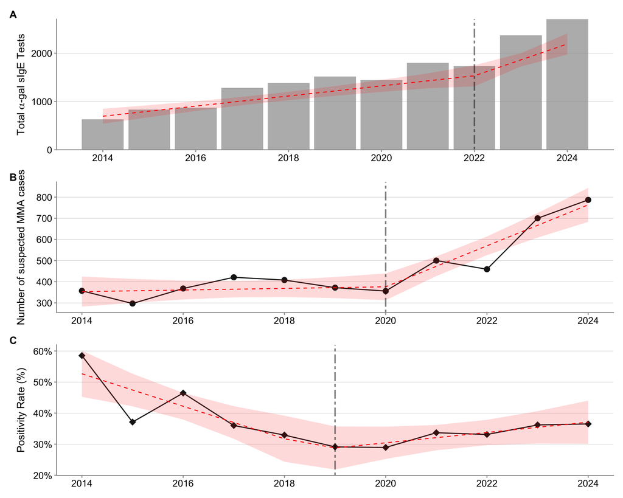

```r
# Combine plots in a row
testing_analysis_three_panel <- p1 /
  p2 /
  p3 +
  plot_annotation(tag_levels = 'A') &
  theme(plot.tag = element_text(face = "bold", size = 12))

print(testing_analysis_three_panel)
```

```r
ggsave(
  "plots/Final_Plots/Fig_2_testing_trends.png",
  testing_analysis_three_panel,
  width = 24,
  height = 20,
  units = "cm",
  bg = "white",
  dpi = 300
)
```

# Testing Volume Decomposition

Decompose the growth in positive case numbers into contributions from changes in testing volume versus changes in positivity rate using counterfactual scenarios.

## Counterfactual Scenarios

Model three counterfactual scenarios against a 2018-2020 baseline: fixing testing volume, fixing positivity rate, or fixing both, to isolate the drivers of increasing case numbers.

```r
annual <- data_no_multi |>
  group_by(Year = YOT) |>
  summarise(
    total_tests = n(),
    positive = sum(Status == "Positive", na.rm = TRUE),
    negative = total_tests - positive,
    positivity_rate = positive / total_tests,
    .groups = "drop"
  )

annual |>
  mutate(
    positivity_pct = round(positivity_rate * 100, 2),
    yoy_tests_pct = round(
      (total_tests / lag(total_tests) - 1) * 100,
      1
    ),
    yoy_cases_pct = round(
      (positive / lag(positive) - 1) * 100,
      1
    )
  )
```

```
# A tibble: 11 × 8
    Year total_tests positive negative positivity_rate positivity_pct
   <int>       <int>    <int>    <int>           <dbl>          <dbl>
 1  2014         610      357      253           0.585           58.5
 2  2015         800      297      503           0.371           37.1
 3  2016         792      368      424           0.465           46.5
 4  2017        1169      421      748           0.360           36.0
 5  2018        1239      408      831           0.329           32.9
 6  2019        1277      372      905           0.291           29.1
 7  2020        1230      356      874           0.289           28.9
 8  2021        1484      500      984           0.337           33.7
 9  2022        1386      459      927           0.331           33.1
10  2023        1934      700     1234           0.362           36.2
11  2024        2155      787     1368           0.365           36.5
# ℹ 2 more variables: yoy_tests_pct <dbl>, yoy_cases_pct <dbl>
```

```r
# Use pooled 2018-2020 as baseline (stable period before post-2020 expansion)
baseline_years <- 2018:2020
baseline <- annual |>
  filter(Year %in% baseline_years) |>
  summarise(
    total_tests = mean(total_tests),
    positive = mean(positive),
    negative = mean(negative),
    positivity_rate = sum(positive) / sum(total_tests) # pooled rate
  )
```

[figure not shown]

```r
baseline_label <- "2018\u20132020"

counterfactual <- annual |>
  mutate(
    # Scenario 1: Testing volume fixed at baseline levels
    cf_fixed_volume = baseline$total_tests * positivity_rate,

    # Scenario 2: Positivity rate fixed at baseline level
    cf_fixed_rate = total_tests * baseline$positivity_rate,

    # Scenario 3: Both fixed (baseline cases)
    cf_both_fixed = baseline$positive
  )

p_counterfactual <- ggplot(counterfactual, aes(x = Year)) +
  # # Shaded region for counterfactual period
  # annotate(
  #   "rect",
  #   xmin = 2020,
  #   xmax = 2024,
  #   ymin = -Inf,
  #   ymax = Inf,
  #   fill = "lightblue",
  #   alpha = 0.3
  # ) +
  geom_line(
    aes(y = positive, colour = "Observed"),
    linewidth = 0.6
  ) +
  geom_point(aes(y = positive, colour = "Observed"), size = 2.5) +
  geom_line(
    aes(
      y = cf_fixed_rate,
      colour = paste0("Positivity rate fixed at ", baseline_label)
    ),
    linewidth = 0.6,
    linetype = "dashed"
  ) +
  geom_line(
    aes(
      y = cf_fixed_volume,
      colour = paste0("Testing volume fixed at ", baseline_label)
    ),
    linewidth = 0.6,
    linetype = "dotted"
  ) +
  scale_colour_manual(
    values = setNames(
      c("grey10", "grey20", "grey30"),
      c(
        "Observed",
        paste0("Positivity rate fixed at ", baseline_label),
        paste0("Testing volume fixed at ", baseline_label)
      )
    )
  ) +
  scale_x_continuous(breaks = 2020:2024) +
  xlim(c(2020, 2024)) +
  ylim(c(300, 800)) +
  labs(
    x = NULL,
    y = "Number of suspected MMA cases",
    colour = NULL
  ) +
  theme(
    axis.text.x = element_text(angle = 45, hjust = 1),
    legend.direction = "vertical",
    legend.position = c(0.98, 0.06),
    legend.justification = c("right", "bottom"),
    legend.text = element_text(size = 9, family = "Ariel"),
    legend.title = element_blank(),
    legend.key.width = unit(1, "cm"), # Add this line - width of rectangle
    legend.key.height = unit(0.4, "cm"), # Add this line - height of rectangle
    legend.box.background = element_rect(
      fill = "white",
      color = "grey70",
      linewidth = 0.5
    ),
    legend.margin = margin(2, 2, 2, 2)
  )

p_counterfactual
```

```r
ggsave(
  "plots/Final_Plots/Fig_S3_counterfactual_scenarios.png",
  p_counterfactual,
  width = 20,
  height = 14,
  units = "cm",
  bg = "white"
)
```

## Geographic Expansion vs Testing Intensity

Decompose testing volume growth into contributions from geographic expansion (more SA3 regions testing) versus increased testing intensity (more tests per region).

```r
# Number of unique SA3 regions testing per year
sa3_expansion <- data_no_multi %>%
  group_by(YOT) %>%
  summarise(
    n_sa3_regions = n_distinct(SA3_code),
    n_tests = n(),
    tests_per_region = n_tests / n_sa3_regions
  )

sa3_expansion
```

```
# A tibble: 11 × 4
     YOT n_sa3_regions n_tests tests_per_region
   <int>         <int>   <int>            <dbl>
 1  2014           153     610             3.99
 2  2015           168     800             4.76
 3  2016           164     792             4.83
 4  2017           197    1169             5.93
 5  2018           194    1239             6.39
 6  2019           211    1277             6.05
 7  2020           225    1230             5.47
 8  2021           219    1484             6.78
 9  2022           228    1386             6.08
10  2023           236    1934             8.19
11  2024           255    2155             8.45
```

```r
# Analyze geographic expansion alongside case growth
geographic_expansion_analysis <- sa3_expansion %>%
  left_join(pos_annual_prop_no_multi, by = c("YOT" = "Year")) %>%
  mutate(
    regions_expansion_pct = (n_sa3_regions / first(n_sa3_regions) - 1) * 100,
    tests_expansion_pct = (n_tests / first(n_tests) - 1) * 100,
    intensity_expansion_pct = (tests_per_region / first(tests_per_region) - 1) *
      100,
    cases_expansion_pct = (positive_tests / first(positive_tests) - 1) * 100
  )

# Test correlation between geographic expansion and cases
cor_regions_cases <- cor.test(
  sa3_expansion$n_sa3_regions,
  pos_annual_prop_no_multi$positive_tests
)

cor_intensity_cases <- cor.test(
  sa3_expansion$tests_per_region,
  pos_annual_prop_no_multi$positive_tests
)

cat("=== GEOGRAPHIC EXPANSION ANALYSIS ===\n")
cat("Regions in 2014:", sa3_expansion$n_sa3_regions[1], "\n")
cat("Regions in 2024:", sa3_expansion$n_sa3_regions[11], "\n")
cat(
  "Increase:",
  sa3_expansion$n_sa3_regions[11] - sa3_expansion$n_sa3_regions[1],
  "regions (",
  round(
    (sa3_expansion$n_sa3_regions[11] / sa3_expansion$n_sa3_regions[1] - 1) *
      100,
    1
  ),
  "%)\n\n"
)

cat("Tests per region 2014:", round(sa3_expansion$tests_per_region[1], 2), "\n")
cat(
  "Tests per region 2024:",
  round(sa3_expansion$tests_per_region[11], 2),
  "\n"
)
cat(
  "Increase:",
  round(
    sa3_expansion$tests_per_region[11] - sa3_expansion$tests_per_region[1],
    2
  ),
  "(",
  round(
    (sa3_expansion$tests_per_region[11] /
      sa3_expansion$tests_per_region[1] -
      1) *
      100,
    1
  ),
  "%)\n\n"
)

cat("Correlation: Geographic reach vs Cases\n")
print(cor_regions_cases)
cat("\nCorrelation: Testing intensity vs Cases\n")
print(cor_intensity_cases)

# Decompose testing growth into geographic vs intensity components
decomposition <- sa3_expansion %>%
  mutate(
    total_tests_predicted = n_sa3_regions[1] * tests_per_region, # If only intensity changed
    total_tests_geographic = n_sa3_regions * tests_per_region[1], # If only reach changed
    geographic_effect = (total_tests_geographic / n_tests[1] - 1) * 100,
    intensity_effect = (total_tests_predicted / n_tests[1] - 1) * 100
  )

cat("\n=== DECOMPOSITION OF TESTING GROWTH ===\n")
print(
  decomposition %>%
    dplyr::select(
      YOT,
      n_sa3_regions,
      tests_per_region,
      geographic_effect,
      intensity_effect
    )
)
```

```
=== GEOGRAPHIC EXPANSION ANALYSIS ===
Regions in 2014: 153
Regions in 2024: 255
Increase: 102 regions ( 66.7 %)

Tests per region 2014: 3.99
Tests per region 2024: 8.45
Increase: 4.46 ( 112 %)

Correlation: Geographic reach vs Cases

    Pearson's product-moment correlation

data:  sa3_expansion$n_sa3_regions and pos_annual_prop_no_multi$positive_tests
t = 3.4935, df = 9, p-value = 0.006793
alternative hypothesis: true correlation is not equal to 0
95 percent confidence interval:
 0.2913949 0.9336350
sample estimates:
      cor
0.7586564


Correlation: Testing intensity vs Cases

    Pearson's product-moment correlation

data:  sa3_expansion$tests_per_region and pos_annual_prop_no_multi$positive_tests
t = 6.6707, df = 9, p-value = 9.155e-05
alternative hypothesis: true correlation is not equal to 0
95 percent confidence interval:
 0.6891904 0.9772440
sample estimates:
      cor
0.9120134


=== DECOMPOSITION OF TESTING GROWTH ===
# A tibble: 11 × 5
     YOT n_sa3_regions tests_per_region geographic_effect intensity_effect
   <int>         <int>            <dbl>             <dbl>            <dbl>
 1  2014           153             3.99              0                 0
 2  2015           168             4.76              9.80             19.4
 3  2016           164             4.83              7.19             21.1
 4  2017           197             5.93             28.8              48.8
 5  2018           194             6.39             26.8              60.2
 6  2019           211             6.05             37.9              51.8
 7  2020           225             5.47             47.1              37.1
 8  2021           219             6.78             43.1              70.0
 9  2022           228             6.08             49.0              52.5
10  2023           236             8.19             54.2             106.
11  2024           255             8.45             66.7             112.
```

### Decomposition Plots

Visualise the geographic expansion and testing intensity decomposition as a three-panel figure.

```r
theme_set(
  theme_classic() +
    theme(
      panel.grid.major.y = element_line(
        colour = "grey60",
        linewidth = 0.1
      ),
      panel.grid.minor = element_blank(),
      axis.text.x = element_text(size = 11),
      axis.text.y = element_text(size = 11),
      axis.title.y = element_text(size = 12),
      axis.title.x = element_blank(),
      axis.line = element_line(colour = "grey60"),
      axis.ticks = element_line(colour = "grey60"),
      text = element_text(family = "Arial")
    )
)
```

```r
# Calculate mean and SE of tests per region across SA3s within each year
sa3_expansion_with_se <- data_no_multi %>%
  group_by(YOT, SA3_code) %>%
  summarise(n_tests = n(), .groups = "drop") %>%
  group_by(YOT) %>%
  summarise(
    n_sa3_regions = n_distinct(SA3_code),
    mean_tests_per_region = mean(n_tests),
    sd_tests = sd(n_tests),
    se_tests = sd(n_tests) / sqrt(n()),
    .groups = "drop"
  )
```

```r
# PLOT 1
# Fit model for geographic expansion
geo_model <- lm(n_sa3_regions ~ YOT, data = sa3_expansion)

# Get predictions with confidence intervals
geo_predictions <- data.frame(
  YOT = sa3_expansion$YOT,
  fit = predict(geo_model, se.fit = TRUE)$fit,
  se = predict(geo_model, se.fit = TRUE)$se.fit
) %>%
  mutate(
    lower = fit - 1.96 * se,
    upper = fit + 1.96 * se
  )

# Plot with confidence band
geo_expansion_with_ci <- ggplot(
  sa3_expansion,
  aes(x = YOT, y = n_sa3_regions)
) +
  geom_ribbon(
    data = geo_predictions,
    aes(y = fit, ymin = lower, ymax = upper),
    fill = "grey70",
    alpha = 0.4
  ) +
  geom_line(color = "black", size = 0.8) +
  geom_point(color = "black", size = 3) +
  scale_x_continuous(breaks = seq(2014, 2024, 2)) +
  labs(
    x = "Year",
    y = "Number of SA3 regions",
    #title = "Geographic Expansion with 95% CI"
  )
```

```r
# PLOT 2
# Bar plot with error bars (SE)
expansion_bar_plot <- sa3_expansion_with_se %>%
  ggplot(aes(x = YOT, y = mean_tests_per_region)) +
  geom_col(fill = "grey60", alpha = 0.7, width = 0.9) +
  geom_errorbar(
    aes(
      ymin = mean_tests_per_region - se_tests,
      ymax = mean_tests_per_region + se_tests
    ),
    width = 0.3,
    size = 0.4,
    colour = "black"
  ) +
  scale_x_continuous(breaks = seq(2014, 2024, 2)) +
  scale_y_continuous(expand = expansion(mult = c(0, 0.05))) +
  labs(
    x = "Year",
    y = "Mean tests per region (± SE)",
    #title = "Testing Intensity Expansion"
  )
```

```r
# PLOT 3
p_contrib <- decomposition %>%
  dplyr::select(YOT, geographic_effect, intensity_effect) %>%
  pivot_longer(-YOT, names_to = "component", values_to = "percent") %>%
  ggplot(aes(x = YOT, y = percent, fill = component)) +
  geom_col(position = "dodge", alpha = 0.7, width = 0.9) +
  scale_fill_manual(
    values = c(
      "geographic_effect" = "grey60",
      "intensity_effect" = "black"
    ),
    labels = c(
      "Geographic Expansion",
      "Testing Intensity"
    )
  ) +
  scale_x_continuous(breaks = seq(2014, 2024, 2)) +
  scale_y_continuous(
    expand = expansion(mult = c(0, 0.05)),
    labels = function(x) paste0(x, "%")
  ) +
  labs(
    x = "Year",
    y = "Contribution to testing growth",
    fill = NULL
  ) +
  theme(
    legend.position = c(0.05, 0.84),
    legend.justification = c("left", "top"),
    legend.text = element_text(size = 10),
    legend.title = element_blank(),
    legend.key.width = unit(1, "cm"), # Add this line - width of rectangle
    legend.key.height = unit(0.4, "cm"), # Add this line - height of rectangle
    legend.box.background = element_rect(
      fill = "white",
      color = "grey70",
      linewidth = 0.5
    ),
    legend.margin = margin(2, 2, 2, 2)
  )
```

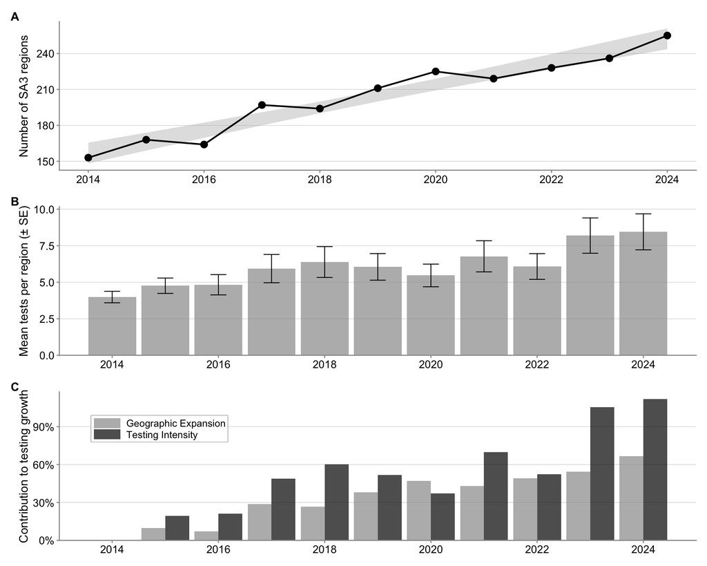

```r
combined_plot <- (geo_expansion_with_ci / expansion_bar_plot / p_contrib) +
  plot_annotation(tag_levels = 'A') &
  theme(plot.tag = element_text(face = "bold", size = 12))

print(combined_plot)
```

```r
ggsave(
  "plots/Final_Plots/Fig_3_volume_decomp.png",
  combined_plot,
  width = 24,
  height = 20,
  units = "cm",
  bg = "white"
)
```

```r
# Finding specific stats for MS from decomp analysis

# Extract values from decomposition table
decomposition_2024 <- decomposition %>%
    filter(YOT == 2024)

# Get baseline values from 2014
baseline_2014 <- decomposition %>%
    filter(YOT == 2014)

# Calculate hypothetical test numbers for each scenario

# Scenario 1: Geographic expansion only (maintaining 2014 intensity)
# = 2024 regions × 2014 tests/region
geographic_only_tests <- decomposition_2024$n_sa3_regions *
    baseline_2014$tests_per_region

# Scenario 2: Intensity increase only (maintaining 2014 regions)
# = 2014 regions × 2024 tests/region
intensity_only_tests <- baseline_2014$n_sa3_regions *
    decomposition_2024$tests_per_region

# Calculate actual baseline tests
baseline_tests <- baseline_2014$n_tests

cat("=== DECOMPOSITION SCENARIO CALCULATIONS ===\n\n")

cat("Baseline (2014):\n")
cat("  Regions:", baseline_2014$n_sa3_regions, "\n")
cat("  Tests per region:", round(baseline_2014$tests_per_region, 1), "\n")
cat("  Total tests:", baseline_tests, "\n\n")

cat("2024 actual values:\n")
cat("  Regions:", decomposition_2024$n_sa3_regions, "\n")
cat("  Tests per region:", round(decomposition_2024$tests_per_region, 1), "\n")
cat("  Total tests:", decomposition_2024$n_tests, "\n\n")

cat("Scenario 1: Geographic expansion only (constant 2014 intensity):\n")
cat(
    "  Calculation:",
    decomposition_2024$n_sa3_regions,
    "regions ×",
    round(baseline_2014$tests_per_region, 1),
    "tests/region\n"
)
cat("  Hypothetical tests:", round(geographic_only_tests, 0), "\n")
cat(
    "  Increase from baseline:",
    round((geographic_only_tests - baseline_tests) / baseline_tests * 100, 1),
    "%\n"
)
cat(
    "  (Matches geographic_effect:",
    round(decomposition_2024$geographic_effect, 1),
    "%)\n\n"
)

cat("Scenario 2: Intensity increase only (constant 2014 regions):\n")
cat(
    "  Calculation:",
    baseline_2014$n_sa3_regions,
    "regions ×",
    round(decomposition_2024$tests_per_region, 1),
    "tests/region\n"
)
cat("  Hypothetical tests:", round(intensity_only_tests, 0), "\n")
cat(
    "  Increase from baseline:",
    round((intensity_only_tests - baseline_tests) / baseline_tests * 100, 1),
    "%\n"
)
cat(
    "  (Matches intensity_effect:",
    round(decomposition_2024$intensity_effect, 1),
    "%)\n\n"
)

cat("=== FOR YOUR STATEMENT ===\n")
cat(
    "If geographic expansion had occurred in isolation (maintaining constant 2014\n"
)
cat(
    "testing intensity of",
    round(baseline_2014$tests_per_region, 1),
    "tests/region/year), total testing volume\n"
)
cat(
    "would have increased by",
    round(decomposition_2024$geographic_effect, 1),
    "% by 2024 (",
    round(geographic_only_tests, 0),
    " tests).\n\n"
)
cat(
    "Conversely, if testing had intensified only within the original",
    baseline_2014$n_sa3_regions,
    "regions\n"
)
cat(
    "(reaching 2024 intensity levels of",
    round(decomposition_2024$tests_per_region, 1),
    "tests/region), volume would have\n"
)
cat(
    "increased by",
    round(decomposition_2024$intensity_effect, 1),
    "% (",
    round(intensity_only_tests, 0),
    " tests).\n"
)
```

```
=== DECOMPOSITION SCENARIO CALCULATIONS ===

Baseline (2014):
  Regions: 153
  Tests per region: 4
  Total tests: 610

2024 actual values:
  Regions: 255
  Tests per region: 8.5
  Total tests: 2155

Scenario 1: Geographic expansion only (constant 2014 intensity):
  Calculation: 255 regions × 4 tests/region
  Hypothetical tests: 1017
  Increase from baseline: 66.7 %
  (Matches geographic_effect: 66.7 %)

Scenario 2: Intensity increase only (constant 2014 regions):
  Calculation: 153 regions × 8.5 tests/region
  Hypothetical tests: 1293
  Increase from baseline: 112 %
  (Matches intensity_effect: 112 %)

=== FOR YOUR STATEMENT ===
If geographic expansion had occurred in isolation (maintaining constant 2014
testing intensity of 4 tests/region/year), total testing volume
would have increased by 66.7 % by 2024 ( 1017  tests).

Conversely, if testing had intensified only within the original 153 regions
(reaching 2024 intensity levels of 8.5 tests/region), volume would have
increased by 112 % ( 1293  tests).
```

```r
# ============================================================
# MULTIPLICATIVE INTERACTION FOR POSITIVE CASES
# ============================================================

# Get positive cases for 2014 and 2024
positive_2014 <- pos_annual_prop_no_multi %>%
  filter(Year == 2014) %>%
  pull(positive_tests)

positive_2024 <- pos_annual_prop_no_multi %>%
  filter(Year == 2024) %>%
  pull(positive_tests)

cat("=== MULTIPLICATIVE INTERACTION ANALYSIS (POSITIVE CASES) ===\n\n")

# Actual increase in positive cases
actual_pos_increase <- positive_2024 - positive_2014
actual_pos_pct <- (actual_pos_increase / positive_2014) * 100

cat("Actual positive cases:\n")
cat("  2014:", positive_2014, "cases\n")
cat("  2024:", positive_2024, "cases\n")
cat("  Absolute increase:", actual_pos_increase, "cases\n")
cat("  Percentage increase:", round(actual_pos_pct, 1), "%\n\n")

# Calculate what positive cases would be under each isolation scenario
# Assume positivity rate stays constant at ~33%
baseline_positivity <- 0.33 # Average positivity rate

# Scenario 1: Geographic expansion only effect on cases
# If only geography expanded: geographic_only_tests * positivity rate
geographic_only_cases <- geographic_only_tests * baseline_positivity

# Scenario 2: Intensity only effect on cases
# If only intensity increased: intensity_only_tests * positivity rate
intensity_only_cases <- intensity_only_tests * baseline_positivity

# Baseline positive cases if maintained
baseline_cases_2014 <- positive_2014

# Individual contributions (relative to baseline)
geographic_contribution_cases <- geographic_only_cases - baseline_cases_2014
intensity_contribution_cases <- intensity_only_cases - baseline_cases_2014
additive_total_cases <- geographic_contribution_cases +
  intensity_contribution_cases

cat("If effects were additive (assuming constant 33% positivity):\n")
cat(
  "  Geographic contribution:",
  round(geographic_contribution_cases, 0),
  "cases\n"
)
cat(
  "  Intensity contribution:",
  round(intensity_contribution_cases, 0),
  "cases\n"
)
cat("  Sum:", round(additive_total_cases, 0), "cases\n")
cat(
  "  Expected total (baseline + sum):",
  round(baseline_cases_2014 + additive_total_cases, 0),
  "cases\n\n"
)

# Interaction effect for positive cases
interaction_effect_cases <- actual_pos_increase - additive_total_cases
interaction_pct_cases <- (interaction_effect_cases / actual_pos_increase) * 100

cat("Multiplicative interaction (positive cases):\n")
cat("  Actual increase:", actual_pos_increase, "cases\n")
cat("  Additive prediction:", round(additive_total_cases, 0), "cases\n")
cat("  Interaction effect:", round(interaction_effect_cases, 0), "cases\n")
cat(
  "  Interaction as % of total growth:",
  round(interaction_pct_cases, 1),
  "%\n\n"
)

# Test interaction using regression on positive cases
# Model positive cases as function of regions, intensity, and their interaction
cases_by_year <- pos_annual_prop_no_multi %>%
  left_join(sa3_expansion, by = c("Year" = "YOT"))

interaction_model_cases <- lm(
  positive_tests ~ n_sa3_regions * tests_per_region,
  data = cases_by_year
)

cat("=== INTERACTION MODEL (POSITIVE CASES) ===\n")
summary(interaction_model_cases)

# Extract interaction p-value
interaction_p_cases <- summary(interaction_model_cases)$coefficients[
  "n_sa3_regions:tests_per_region",
  "Pr(>|t|)"
]

cat(
  "\nInteraction term p-value:",
  format.pval(interaction_p_cases, digits = 4),
  "\n"
)

cat("\n=== FINAL STATEMENT (POSITIVE CASES) ===\n")
cat(
  "The observed total increase of",
  round(actual_pos_pct, 0),
  "% (",
  actual_pos_increase,
  " cases) demonstrates a multiplicative rather than\n"
)
cat(
  "additive effect, with the interaction between geographic expansion and regional\n"
)
cat(
  "intensification accounting for",
  round(interaction_pct_cases, 1),
  "% of the total growth (",
  round(interaction_effect_cases, 0),
  " cases, p ",
  ifelse(
    interaction_p_cases < 0.001,
    "< 0.001",
    paste("=", round(interaction_p_cases, 3))
  ),
  ").\n"
)
```

```
=== MULTIPLICATIVE INTERACTION ANALYSIS (POSITIVE CASES) ===

Actual positive cases:
  2014: 357 cases
  2024: 787 cases
  Absolute increase: 430 cases
  Percentage increase: 120.4 %

If effects were additive (assuming constant 33% positivity):
  Geographic contribution: -22 cases
  Intensity contribution: 70 cases
  Sum: 48 cases
  Expected total (baseline + sum): 405 cases

Multiplicative interaction (positive cases):
  Actual increase: 430 cases
  Additive prediction: 48 cases
  Interaction effect: 382 cases
  Interaction as % of total growth: 88.8 %

=== INTERACTION MODEL (POSITIVE CASES) ===

Call:
lm(formula = positive_tests ~ n_sa3_regions * tests_per_region,
    data = cases_by_year)

Residuals:
    Min      1Q  Median      3Q     Max
-41.919 -11.247   9.724  17.798  28.636

Coefficients:
                                Estimate Std. Error t value Pr(>|t|)
(Intercept)                    1420.9321   263.7929   5.387 0.001023 **
n_sa3_regions                    -7.2428     1.2442  -5.821 0.000649 ***
tests_per_region               -196.8121    54.4512  -3.614 0.008573 **
n_sa3_regions:tests_per_region    1.3400     0.2246   5.966 0.000561 ***
---
Signif. codes:  0 '***' 0.001 '**' 0.01 '*' 0.05 '.' 0.1 ' ' 1

Residual standard error: 29.91 on 7 degrees of freedom
Multiple R-squared:  0.9733,    Adjusted R-squared:  0.9618
F-statistic:    85 on 3 and 7 DF,  p-value: 7.182e-06


Interaction term p-value: 0.0005608

=== FINAL STATEMENT (POSITIVE CASES) ===
The observed total increase of 120 % ( 430  cases) demonstrates a multiplicative rather than
additive effect, with the interaction between geographic expansion and regional
intensification accounting for 88.8 % of the total growth ( 382  cases, p  < 0.001 ).
```

```r
# Model testing volume as product of regions × intensity
model <- lm(n_tests ~ n_sa3_regions * tests_per_region, data = sa3_expansion)
summary(model)
# The interaction term p-value would be your test
```

```
Call:
lm(formula = n_tests ~ n_sa3_regions * tests_per_region, data = sa3_expansion)

Residuals:
       Min         1Q     Median         3Q        Max
-1.332e-13 -2.086e-14  1.151e-14  3.873e-14  7.325e-14

Coefficients:
                                 Estimate Std. Error    t value Pr(>|t|)
(Intercept)                    -7.700e-14  6.552e-13 -1.180e-01    0.910
n_sa3_regions                   1.972e-15  3.090e-15  6.380e-01    0.544
tests_per_region               -5.366e-14  1.352e-13 -3.970e-01    0.703
n_sa3_regions:tests_per_region  1.000e+00  5.578e-16  1.793e+15   <2e-16 ***
---
Signif. codes:  0 '***' 0.001 '**' 0.01 '*' 0.05 '.' 0.1 ' ' 1

Residual standard error: 7.43e-14 on 7 degrees of freedom
Multiple R-squared:      1, Adjusted R-squared:      1
F-statistic: 1.316e+32 on 3 and 7 DF,  p-value: < 2.2e-16
```

```r
# Compare observed growth to what would happen under additive model
decomposition_test <- sa3_expansion %>%
  filter(YOT %in% c(2014, 2024)) %>%
  summarise(
    regions_2014 = first(n_sa3_regions),
    regions_2024 = last(n_sa3_regions),
    intensity_2014 = first(tests_per_region),
    intensity_2024 = last(tests_per_region),
    tests_2014 = first(n_tests),
    tests_2024 = last(n_tests),

    # Observed increase
    observed_increase = (tests_2024 - tests_2014) / tests_2014 * 100,

    # Expected under additive model
    geographic_only = (regions_2024 - regions_2014) * intensity_2014,
    intensity_only = (intensity_2024 - intensity_2014) * regions_2014,
    additive_expected = tests_2014 + geographic_only + intensity_only,
    additive_increase = (additive_expected - tests_2014) / tests_2014 * 100,

    # Expected under multiplicative model
    multiplicative_expected = regions_2024 * intensity_2024,
    multiplicative_increase = (multiplicative_expected - tests_2014) /
      tests_2014 *
      100,

    # Which model fits better?
    observed_vs_additive_diff = abs(tests_2024 - additive_expected),
    observed_vs_mult_diff = abs(tests_2024 - multiplicative_expected)
  )

cat("=== ADDITIVE vs MULTIPLICATIVE MODEL COMPARISON ===\n")
print(decomposition_test)
```

```
=== ADDITIVE vs MULTIPLICATIVE MODEL COMPARISON ===
# A tibble: 1 × 15
  regions_2014 regions_2024 intensity_2014 intensity_2024 tests_2014 tests_2024
         <int>        <int>          <dbl>          <dbl>      <int>      <int>
1          153          255           3.99           8.45        610       2155
# ℹ 9 more variables: observed_increase <dbl>, geographic_only <dbl>,
#   intensity_only <dbl>, additive_expected <dbl>, additive_increase <dbl>,
#   multiplicative_expected <dbl>, multiplicative_increase <dbl>,
#   observed_vs_additive_diff <dbl>, observed_vs_mult_diff <dbl>
```

```r
# Alternative: Cumulative cases decomposition
cat("=== CUMULATIVE CASES ANALYSIS ===\n\n")

# Total unique cases detected
total_unique_cases <- 5025

# What would cumulative cases be under isolation scenarios?
# Sum across all years

# Calculate cumulative effects
cumulative_geographic <- sum(decomposition$total_tests_geographic * 0.33) # All years, geographic only
cumulative_intensity <- sum(decomposition$total_tests_predicted * 0.33) # All years, intensity only
cumulative_actual <- total_unique_cases

cat("Cumulative analysis (2014-2024):\n")
cat("  Actual total cases:", total_unique_cases, "\n")
cat("  If only geographic expansion:", round(cumulative_geographic, 0), "\n")
cat("  If only intensity increase:", round(cumulative_intensity, 0), "\n")
cat(
    "  Additive prediction:",
    round(cumulative_geographic + cumulative_intensity, 0),
    "\n"
)
cat(
    "  Interaction effect:",
    round(
        cumulative_actual - (cumulative_geographic + cumulative_intensity),
        0
    ),
    "\n"
)
```

```
=== CUMULATIVE CASES ANALYSIS ===

Cumulative analysis (2014-2024):
  Actual total cases: 5025
  If only geographic expansion: 2960
  If only intensity increase: 3379
  Additive prediction: 6339
  Interaction effect: -1314
```

```r
# Better approach: Test interaction using regression
interaction_model <- lm(
  n_tests ~ n_sa3_regions * tests_per_region,
  data = decomposition
)

cat("\n=== INTERACTION MODEL ===\n")
summary(interaction_model)

# Extract interaction p-value
interaction_p <- summary(interaction_model)$coefficients[
  "n_sa3_regions:tests_per_region",
  "Pr(>|t|)"
]

cat("\nInteraction term p-value:", format.pval(interaction_p, digits = 4), "\n")
```

```
=== INTERACTION MODEL ===

Call:
lm(formula = n_tests ~ n_sa3_regions * tests_per_region, data = decomposition)

Residuals:
       Min         1Q     Median         3Q        Max
-1.332e-13 -2.086e-14  1.151e-14  3.873e-14  7.325e-14

Coefficients:
                                 Estimate Std. Error    t value Pr(>|t|)
(Intercept)                    -7.700e-14  6.552e-13 -1.180e-01    0.910
n_sa3_regions                   1.972e-15  3.090e-15  6.380e-01    0.544
tests_per_region               -5.366e-14  1.352e-13 -3.970e-01    0.703
n_sa3_regions:tests_per_region  1.000e+00  5.578e-16  1.793e+15   <2e-16 ***
---
Signif. codes:  0 '***' 0.001 '**' 0.01 '*' 0.05 '.' 0.1 ' ' 1

Residual standard error: 7.43e-14 on 7 degrees of freedom
Multiple R-squared:      1, Adjusted R-squared:      1
F-statistic: 1.316e+32 on 3 and 7 DF,  p-value: < 2.2e-16


Interaction term p-value: < 2.2e-16
```

## Testing intensity heterogeneity

```r
# Calculate change in testing intensity for each SA3 region
# Need to get first and last year of testing for each region

sa3_intensity_change <- data_no_multi %>%
  group_by(SA3_code) %>%
  summarise(
    first_year = min(YOT),
    last_year = max(YOT),
    n_tests_first = sum(YOT == first_year),
    n_tests_last = sum(YOT == last_year),
    years_testing = n_distinct(YOT),
    .groups = "drop"
  ) %>%
  # Calculate intensity change
  mutate(
    intensity_change = n_tests_last - n_tests_first,
    intensity_pct_change = ifelse(
      n_tests_first > 0,
      (intensity_change / n_tests_first) * 100,
      NA
    )
  ) %>%
  # Filter to regions testing in multiple years
  filter(years_testing >= 2, !is.na(intensity_pct_change))

cat("=== TESTING INTENSITY HETEROGENEITY ===\n\n")

# Summary statistics
intensity_summary <- sa3_intensity_change %>%
  summarise(
    n_regions = n(),
    median_change = median(intensity_pct_change, na.rm = TRUE),
    mean_change = mean(intensity_pct_change, na.rm = TRUE),
    sd_change = sd(intensity_pct_change, na.rm = TRUE),
    q25 = quantile(intensity_pct_change, 0.25, na.rm = TRUE),
    q75 = quantile(intensity_pct_change, 0.75, na.rm = TRUE),
    iqr = IQR(intensity_pct_change, na.rm = TRUE),
    min_change = min(intensity_pct_change, na.rm = TRUE),
    max_change = max(intensity_pct_change, na.rm = TRUE)
  )

print(intensity_summary)

cat(
  "\nMedian intensity change:",
  round(intensity_summary$median_change, 1),
  "%\n"
)
cat(
  "IQR:",
  round(intensity_summary$q25, 1),
  "% to",
  round(intensity_summary$q75, 1),
  "% (range:",
  round(intensity_summary$iqr, 1),
  "%)\n\n"
)

# Test for heterogeneity using coefficient of variation
cv <- (intensity_summary$sd_change / abs(intensity_summary$mean_change)) * 100
cat("Coefficient of Variation:", round(cv, 1), "%\n")
cat("(CV > 30% indicates high heterogeneity)\n\n")

# Statistical test: Levene's test for homogeneity of variance
# Compare variance across different testing eras
sa3_intensity_by_era <- sa3_intensity_change %>%
  mutate(
    testing_era = case_when(
      first_year <= 2016 ~ "Early",
      first_year <= 2019 ~ "Pre-COVID",
      first_year <= 2021 ~ "COVID",
      TRUE ~ "Recent"
    )
  )

# Levene's test
library(car)
levene_test <- leveneTest(
  intensity_pct_change ~ as.factor(testing_era),
  data = sa3_intensity_by_era
)

cat("=== LEVENE'S TEST (Homogeneity of Variance) ===\n")
print(levene_test)
cat(
  "\nInterpretation: p",
  ifelse(
    levene_test$`Pr(>F)`[1] < 0.001,
    "< 0.001",
    paste("=", round(levene_test$`Pr(>F)`[1], 3))
  ),
  ifelse(
    levene_test$`Pr(>F)`[1] < 0.05,
    " - Significant heterogeneity detected",
    " - No significant heterogeneity"
  ),
  "\n\n"
)

# Kruskal-Wallis test: Are intensity changes different across eras?
kruskal_test <- kruskal.test(
  intensity_pct_change ~ testing_era,
  data = sa3_intensity_by_era
)

cat("=== KRUSKAL-WALLIS TEST (Regional Differences) ===\n")
print(kruskal_test)
cat(
  "\nInterpretation: p",
  ifelse(
    kruskal_test$p.value < 0.001,
    "< 0.001",
    paste("=", round(kruskal_test$p.value, 3))
  ),
  ifelse(
    kruskal_test$p.value < 0.05,
    " - Significant differences across regions",
    " - No significant differences"
  ),
  "\n\n"
)


cat("=== FOR YOUR STATEMENT ===\n")
cat(
  "However, this intensification showed considerable heterogeneity across regions,\n"
)
cat(
  "with the median increase being",
  round(intensity_summary$median_change, 1),
  "% and interquartile range of\n"
)
cat(
  round(intensity_summary$q25, 1),
  "% to",
  round(intensity_summary$q75, 1),
  "% (IQR = ",
  round(intensity_summary$iqr, 1),
  "%, CV = ",
  round(cv, 1),
  "%, Levene's test p ",
  ifelse(
    levene_test$`Pr(>F)`[1] < 0.001,
    "< 0.001",
    paste("=", round(levene_test$`Pr(>F)`[1], 3))
  ),
  ").\n"
)
```

```
=== TESTING INTENSITY HETEROGENEITY ===

# A tibble: 1 × 9
  n_regions median_change mean_change sd_change   q25   q75   iqr min_change
      <int>         <dbl>       <dbl>     <dbl> <dbl> <dbl> <dbl>      <dbl>
1       295          66.7        155.      297.     0   200   200        -90
# ℹ 1 more variable: max_change <dbl>

Median intensity change: 66.7 %
IQR: 0 % to 200 % (range: 200 %)

Coefficient of Variation: 192 %
(CV > 30% indicates high heterogeneity)

=== LEVENE'S TEST (Homogeneity of Variance) ===
Levene's Test for Homogeneity of Variance (center = median)
       Df F value   Pr(>F)
group   3   4.739 0.003038 **
      291
---
Signif. codes:  0 '***' 0.001 '**' 0.01 '*' 0.05 '.' 0.1 ' ' 1

Interpretation: p = 0.003  - Significant heterogeneity detected

=== KRUSKAL-WALLIS TEST (Regional Differences) ===

    Kruskal-Wallis rank sum test

data:  intensity_pct_change by testing_era
Kruskal-Wallis chi-squared = 22.068, df = 3, p-value = 6.314e-05


Interpretation: p < 0.001  - Significant differences across regions

=== FOR YOUR STATEMENT ===
However, this intensification showed considerable heterogeneity across regions,
with the median increase being 66.7 % and interquartile range of
0 % to 200 % (IQR =  200 %, CV =  192 %, Levene's test p  = 0.003 ).
```

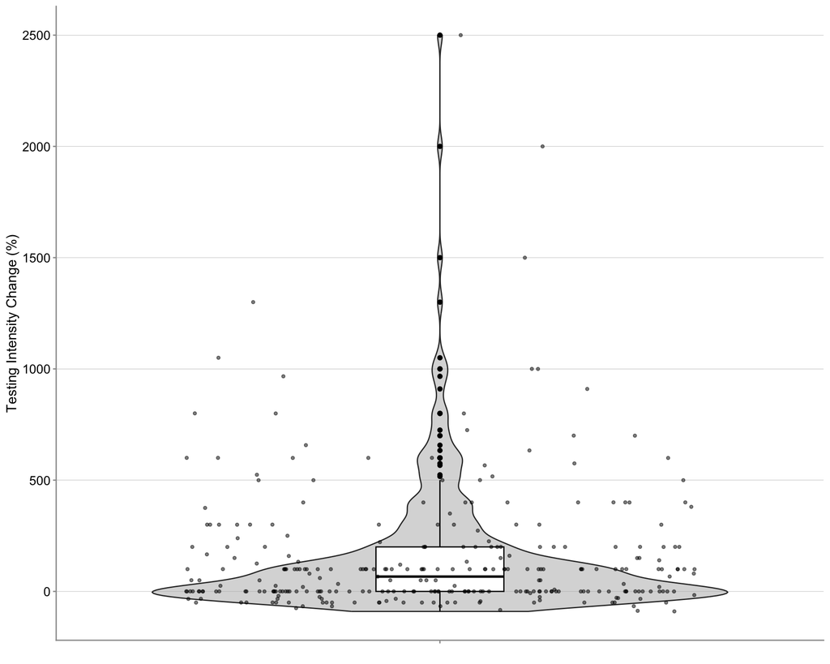

```r
# Visualize heterogeneity
heterogeneity_plot <- ggplot(
  sa3_intensity_change,
  aes(x = "", y = intensity_pct_change)
) +
  geom_violin(fill = "grey70", alpha = 0.5) +
  geom_boxplot(
    width = 0.2,
    fill = "white",
    alpha = 1,
    linewidth = 0.5,
    colour = "black"
  ) +
  geom_jitter(width = 0.4, alpha = 0.5, size = 1) +
  labs(
    x = NULL,
    y = "Testing Intensity Change (%)",
    #title = "Heterogeneity in Regional Testing Intensity Changes"
  )

print(heterogeneity_plot)
```

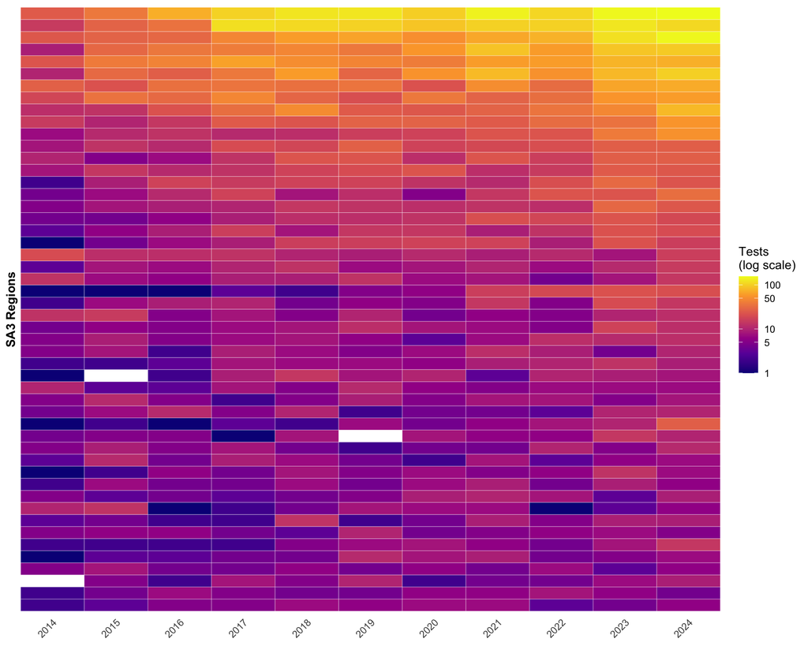

```
Years in data: 2014 2015 2016 2017 2018 2019 2020 2021 2022 2023 2024
```

```r
# Calculate annual intensity for each region
regional_intensity_annual <- data_no_multi %>%
  group_by(SA3_code, YOT) %>%
  summarise(n_tests = n(), .groups = "drop") %>%
  group_by(SA3_code) %>%
  filter(n() >= 3) %>% # Regions with at least 3 years
  ungroup() %>%
  arrange(SA3_code, YOT)

# Select top n regions by total tests for visualization

num = 50

top_regions <- regional_intensity_annual %>%
  group_by(SA3_code) %>%
  summarise(total = sum(n_tests)) %>%
  slice_max(order_by = total, n = num) %>%
  pull(SA3_code)

# Check what years are actually in your data
cat("Years in data:", sort(unique(regional_intensity_annual$YOT)), "\n")

# Filter to only 2014-2024 explicitly
regional_intensity_annual_filtered <- regional_intensity_annual %>%
  filter(YOT >= 2014, YOT <= 2024)

heatmap_plot <- regional_intensity_annual_filtered %>%
  filter(SA3_code %in% top_regions) %>%
  ggplot(aes(
    x = YOT,
    y = reorder(SA3_code, n_tests, FUN = sum),
    fill = n_tests
  )) +
  geom_tile(color = "white", size = 0.1) + # Add white borders between tiles
  scale_fill_viridis_c(
    option = "C",
    trans = "log10",
    breaks = c(1, 5, 10, 50, 100, 500),
    labels = c("1", "5", "10", "50", "100", "500")
  ) +
  scale_x_continuous(
    breaks = 2014:2024, # Show all years
    limits = c(2013.5, 2024.5), # Slightly wider to show edge tiles
    expand = c(0, 0)
  ) +
  labs(
    x = "Year",
    y = "SA3 Regions",
    fill = "Tests\n(log scale)"
  ) +
  theme_minimal() +
  theme(
    axis.text.y = element_blank(),
    axis.ticks.y = element_blank(),
    axis.text.x = element_text(angle = 45, hjust = 1),
    panel.grid = element_blank(),
    axis.title.y = element_text(face = "bold"),
    axis.title.x = element_blank(),
    text = element_text(family = "Arial")
  )

print(heatmap_plot)
```

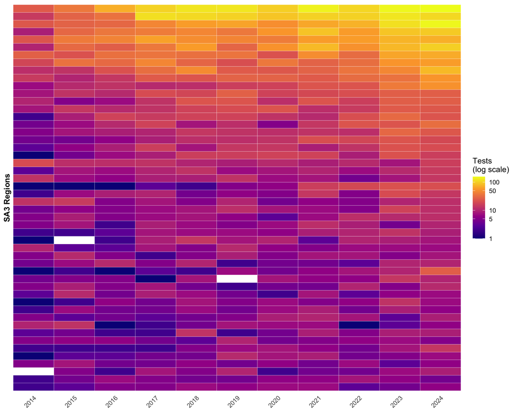

```
Years in data: 2014 2015 2016 2017 2018 2019 2020 2021 2022 2023 2024
```

```r
# Calculate annual intensity for each region
regional_intensity_annual <- data_no_multi %>%
  group_by(SA3_code, YOT) %>%
  summarise(n_tests = n(), .groups = "drop") %>%
  group_by(SA3_code) %>%
  filter(n() >= 3) %>% # Regions with at least 3 years
  ungroup() %>%
  arrange(SA3_code, YOT)

# Select top n regions by total tests for visualization

num = 50

top_regions <- regional_intensity_annual %>%
  group_by(SA3_code) %>%
  summarise(total = sum(n_tests)) %>%
  slice_max(order_by = total, n = num) %>%
  pull(SA3_code)

# Check what years are actually in your data
cat("Years in data:", sort(unique(regional_intensity_annual$YOT)), "\n")

# Filter to only 2014-2024 explicitly
regional_intensity_annual_filtered <- regional_intensity_annual %>%
  filter(YOT >= 2014, YOT <= 2024)

heatmap_plot <- regional_intensity_annual_filtered %>%
  filter(SA3_code %in% top_regions) %>%
  ggplot(aes(
    x = YOT,
    y = reorder(SA3_code, n_tests, FUN = sum),
    fill = n_tests
  )) +
  geom_tile(color = "white", size = 0.1) + # Add white borders between tiles
  scale_fill_viridis_c(
    option = "C",
    trans = "log10",
    breaks = c(1, 5, 10, 50, 100, 500),
    labels = c("1", "5", "10", "50", "100", "500")
  ) +
  scale_x_continuous(
    breaks = 2014:2024, # Show all years
    limits = c(2013.5, 2024.5), # Slightly wider to show edge tiles
    expand = c(0, 0)
  ) +
  labs(
    x = "Year",
    y = "SA3 Regions",
    fill = "Tests\n(log scale)"
  ) +
  theme_minimal() +
  theme(
    axis.text.y = element_blank(),
    axis.ticks.y = element_blank(),
    axis.text.x = element_text(angle = 45, hjust = 1),
    panel.grid = element_blank(),
    axis.title.y = element_text(face = "bold"),
    axis.title.x = element_blank(),
    text = element_text(family = "Arial")
  )

print(heatmap_plot)
```

# Stats: Does testing volume explain incrased in pos cases?

```r
models_analysis <- pos_annual_prop_no_multi %>%
  filter(Year >= 2014, Year <= 2024) %>%
  summarise(
    # Model 1: Time trend only
    model_time = list(lm(positive_tests ~ Year, data = .)),
    # Model 2: Testing volume only
    model_volume = list(lm(positive_tests ~ total_tests, data = .)),
    # Model 3: Both time and volume
    model_combined = list(lm(positive_tests ~ Year + total_tests, data = .))
  )

# Extract model summaries
cat("=== MODEL 1: Time Trend Only ===\n")
summary(models_analysis$model_time[[1]])

cat("\n=== MODEL 2: Testing Volume Only ===\n")
summary(models_analysis$model_volume[[1]])

cat("\n=== MODEL 3: Combined (Time + Volume) ===\n")
summary(models_analysis$model_combined[[1]])

# Compare model fit
model_comparison <- data.frame(
  Model = c("Time Only", "Volume Only", "Time + Volume"),
  R_squared = c(
    summary(models_analysis$model_time[[1]])$r.squared,
    summary(models_analysis$model_volume[[1]])$r.squared,
    summary(models_analysis$model_combined[[1]])$r.squared
  ),
  AIC = c(
    AIC(models_analysis$model_time[[1]]),
    AIC(models_analysis$model_volume[[1]]),
    AIC(models_analysis$model_combined[[1]])
  )
)

print("Model Comparison:")
print(model_comparison)
```

```
=== MODEL 1: Time Trend Only ===

Call:
lm(formula = positive_tests ~ Year, data = .)

Residuals:
     Min       1Q   Median       3Q      Max
-138.464  -58.464   -9.236   63.941  141.955

Coefficients:
              Estimate Std. Error t value Pr(>|t|)
(Intercept) -75549.355  17984.916  -4.201  0.00230 **
Year            37.645      8.908   4.226  0.00222 **
---
Signif. codes:  0 '***' 0.001 '**' 0.01 '*' 0.05 '.' 0.1 ' ' 1

Residual standard error: 93.43 on 9 degrees of freedom
Multiple R-squared:  0.6649,    Adjusted R-squared:  0.6277
F-statistic: 17.86 on 1 and 9 DF,  p-value: 0.002219


=== MODEL 2: Testing Volume Only ===

Call:
lm(formula = positive_tests ~ total_tests, data = .)

Residuals:
   Min     1Q Median     3Q    Max
-85.90 -33.20 -15.67  52.13 101.43

Coefficients:
            Estimate Std. Error t value Pr(>|t|)
(Intercept) 72.25034   59.26234   1.219    0.254
total_tests  0.30053    0.04374   6.871  7.3e-05 ***
---
Signif. codes:  0 '***' 0.001 '**' 0.01 '*' 0.05 '.' 0.1 ' ' 1

Residual standard error: 64.58 on 9 degrees of freedom
Multiple R-squared:  0.8399,    Adjusted R-squared:  0.8221
F-statistic: 47.21 on 1 and 9 DF,  p-value: 7.302e-05
```

[output cut: 13 more lines]

```
(Intercept) 47107.2139 37307.3356   1.263   0.2423
Year          -23.3959    18.5572  -1.261   0.2429
total_tests     0.4579     0.1318   3.474   0.0084 **
---
Signif. codes:  0 '***' 0.001 '**' 0.01 '*' 0.05 '.' 0.1 ' ' 1

Residual standard error: 62.57 on 8 degrees of freedom
Multiple R-squared:  0.8664,    Adjusted R-squared:  0.833
F-statistic: 25.94 on 2 and 8 DF,  p-value: 0.0003184

[1] "Model Comparison:"
          Model R_squared      AIC
1     Time Only 0.6649295 134.8270
2   Volume Only 0.8398782 126.7045
3 Time + Volume 0.8664188 126.7111
```

Does this relationship change over different time periods?

```r
period_analysis <- pos_annual_prop_no_multi %>%
  filter(Year >= 2014, Year <= 2024) %>%
  mutate(
    Period = case_when(
      Year <= 2019 ~ "Pre-COVID (2014-2019)",
      Year >= 2020 & Year <= 2021 ~ "COVID Impact (2020-2021)",
      Year >= 2022 ~ "Post-COVID (2022-2024)"
    )
  ) %>%
  group_by(Period) %>%
  summarise(
    years = paste(min(Year), "-", max(Year)),
    avg_total_tests = round(mean(total_tests)),
    avg_positive_tests = round(mean(positive_tests)),
    avg_positivity_rate = round(mean(pos_prop), 2),
    correlation_vol_vs_pos = cor(
      total_tests,
      positive_tests,
      use = "complete.obs"
    ),
    .groups = "drop"
  )

print("Period-Specific Analysis:")
print(period_analysis)
```

```
[1] "Period-Specific Analysis:"
# A tibble: 3 × 6
  Period            years avg_total_tests avg_positive_tests avg_positivity_rate
  <chr>             <chr>           <dbl>              <dbl>               <dbl>
1 COVID Impact (20… 2020…            1357                428                31.3
2 Post-COVID (2022… 2022…            1825                649                35.3
3 Pre-COVID (2014-… 2014…             981                370                40.0
# ℹ 1 more variable: correlation_vol_vs_pos <dbl>
```

## Decomp: testing volume vs pos rate contributions to case growth

Decomposes the observed change in positive cases into three additive components: - **Volume effect**: more tests at the baseline positivity rate - **Rate effect**: higher positivity rate applied to baseline test volume - **Interaction**: joint change in both

```r
# Decompose case growth: volume effect vs rate effect vs interaction
decomp_cases <- pos_annual_prop_no_multi %>%
  arrange(Year) %>%
  mutate(
    tests_0 = first(total_tests),
    rate_0 = first(pos_prop) / 100,
    cases_0 = first(positive_tests),

    # Additive decomposition: Cases = Tests × Rate
    volume_effect = (total_tests - tests_0) * rate_0,
    rate_effect = tests_0 * (pos_prop / 100 - rate_0),
    interaction_effect = (total_tests - tests_0) * (pos_prop / 100 - rate_0),

    # Observed change
    cases_change = positive_tests - cases_0,

    # Percentage attribution (of observed case change)
    pct_volume = ifelse(
      cases_change != 0,
      volume_effect / cases_change * 100,
      NA
    ),
    pct_rate = ifelse(cases_change != 0, rate_effect / cases_change * 100, NA),
    pct_interaction = ifelse(
      cases_change != 0,
      interaction_effect / cases_change * 100,
      NA
    )
  )

cat("=== CASE GROWTH DECOMPOSITION ===\n\n")
decomp_cases %>%
  dplyr::select(
    Year,
    cases_change,
    volume_effect,
    rate_effect,
    interaction_effect,
    pct_volume,
    pct_rate,
    pct_interaction
  ) %>%
  print(n = 11)

# Summary for 2024 vs 2014 baseline
d2024 <- decomp_cases %>% filter(Year == 2024)
cat("\n=== 2024 vs 2014 BASELINE ===\n")
cat("Observed case increase:", d2024$cases_change, "\n")
cat(
  "Volume effect:",
  round(d2024$volume_effect, 1),
  "(",
  round(d2024$pct_volume, 1),
  "%)\n"
)
cat(
  "Rate effect:",
  round(d2024$rate_effect, 1),
  "(",
  round(d2024$pct_rate, 1),
  "%)\n"
)
cat(
  "Interaction:",
  round(d2024$interaction_effect, 1),
  "(",
  round(d2024$pct_interaction, 1),
  "%)\n"
)
cat(
  "Sum of components:",
  round(d2024$volume_effect + d2024$rate_effect + d2024$interaction_effect, 1),
  "\n"
)
```

```
=== CASE GROWTH DECOMPOSITION ===

# A tibble: 11 × 8
    Year cases_change volume_effect rate_effect interaction_effect pct_volume
   <int>        <int>         <dbl>       <dbl>              <dbl>      <dbl>
 1  2014            0            0          0                  0          NA
 2  2015          -60          111.      -131.               -40.7      -185.
 3  2016           11          107.       -73.6              -21.9       968.
 4  2017           64          327.      -137.              -126.        511.
 5  2018           51          368.      -156.              -161.        722.
 6  2019           15          390.      -179.              -196.       2602.
 7  2020           -1          363.      -180.              -183.     -36282.
 8  2021          143          511.      -151.              -217.        358.
 9  2022          102          454.      -155.              -197.        445.
10  2023          343          775.      -136.              -296.        226.
11  2024          430          904.      -134.              -340.        210.
# ℹ 2 more variables: pct_rate <dbl>, pct_interaction <dbl>

=== 2024 vs 2014 BASELINE ===
Observed case increase: 430
Volume effect: 904.1 ( 210.3 %)
Rate effect: -134.2 ( -31.2 %)
Interaction: -339.9 ( -79 %)
Sum of components: 430
```

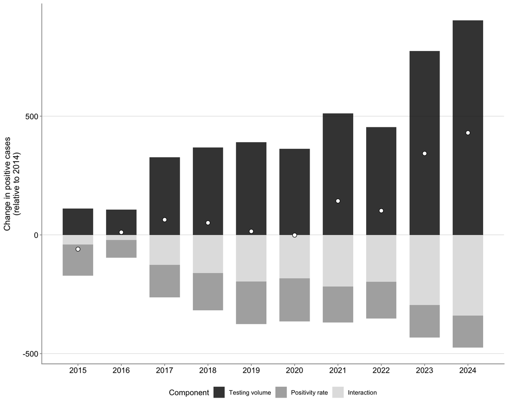

```r
# Visualise decomposition over time
decomp_long <- decomp_cases %>%
  filter(Year > 2014) %>%
  dplyr::select(Year, volume_effect, rate_effect, interaction_effect) %>%
  pivot_longer(-Year, names_to = "component", values_to = "cases") %>%
  mutate(
    component = factor(
      component,
      levels = c("volume_effect", "rate_effect", "interaction_effect"),
      labels = c("Testing volume", "Positivity rate", "Interaction")
    )
  )

# Stacked bar chart of absolute contributions
p_decomp_abs <- ggplot(
  decomp_long,
  aes(x = Year, y = cases, fill = component)
) +
  geom_col(alpha = 0.8, width = 0.7) +
  geom_point(
    data = decomp_cases %>% filter(Year > 2014),
    aes(x = Year, y = cases_change, fill = NULL),
    shape = 21,
    size = 2.5,
    fill = "white",
    colour = "black"
  ) +
  scale_fill_manual(
    values = c(
      "Testing volume" = "black",
      "Positivity rate" = "grey60",
      "Interaction" = "grey85"
    )
  ) +
  scale_x_continuous(breaks = seq(2015, 2024, 1)) +
  scale_y_continuous(expand = expansion(mult = c(0.05, 0.05))) +
  labs(
    x = "Year",
    y = "Change in positive cases\n(relative to 2014)",
    fill = "Component"
  ) +
  theme(legend.position = "bottom")

p_decomp_abs
```